# How Fast is Asia Growing?

Cyrus Tadjiki

24 November 2021

## 1) Data

I collected my data from an open source of world population data by country from the year 1500 to 2000. [Our World Data](https://ourworldindata.org/grapher/population-by-country) is the site that I download my data from. Some country codes were missing so I had to add them manually but this data didn’t contain any missing values.

## 3) Plots

### Population of Continents

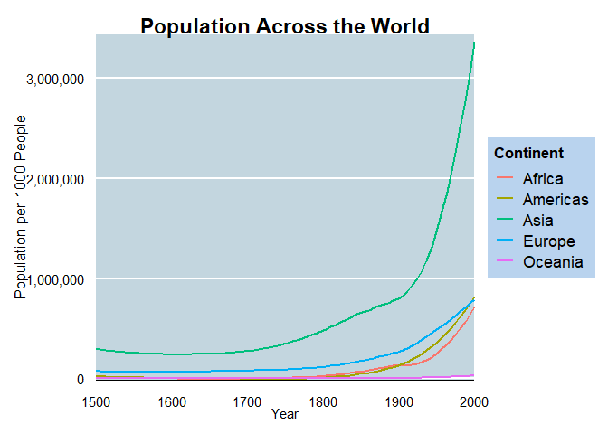

### Asia versus the rest of the World

Further investigating population I compared Asia to the rest of the world. They completely dominate the rate of growth and looks like nothing is stopping it from slowing down. I wonder if China accounts for a large portion of this growth. They are the only country to have ever had a one child policy in their country which occurred from 1980-2015.

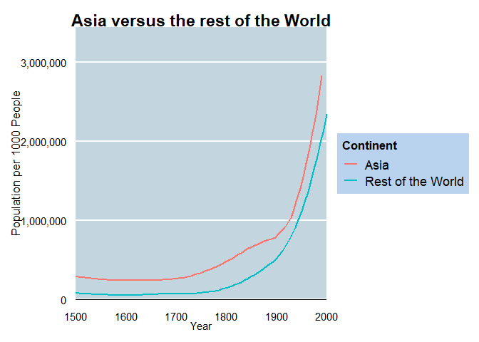

### China versus Asia

Is China the main factor for Asia’s population? Here we see they were till 1900. Next I will show you what other countries could be contributing to this growth.

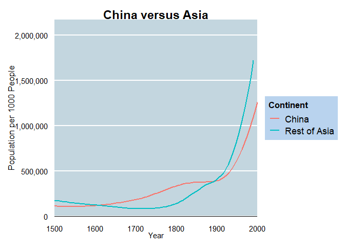

### Top Ten Most Populated Asian Countries

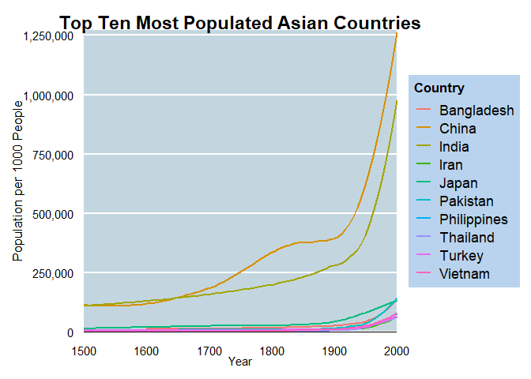

## 4) Fixed Effect of One Child Policy in China

```r
data = data %>% mutate(one_child_policy = ifelse(1980 <= year & year <= 2015 & code == "CHN", 1, 0))
china_vs_asia = china_vs_asia %>% mutate(one_child_policy = ifelse(1980 <= year & year <= 2015 & Continent == "China", 1, 0))

reg_fe_china_vs_wd = felm(population~one_child_policy|year + country_name, data = data)
reg_fe_china_vs_asia = felm(population~one_child_policy|year + Continent, data = china_vs_asia)
```

|  | *Dependent variable:* |  |
| --- | --- | --- |
|  | Population |  |
|  | China v. World | China v. Asia |
|  | (1) | (2) |
| One Child Policy | 722,027.700*** | -698,237.100*** |
|  | (15,820.300) | (104,554.700) |
| Observations | 3,221 | 52 |
| R<sup>2</sup> | 0.840 | 0.964 |
| *Note:* | p<0.1; p<0.05; p<0.01 |  |

**Running a fixed effect linear regression holding country and year constant comparing China’s population in 1980, 1990 and 2000 to the rest of the world form 1500 to 2000 this shows us that China’s one child policy had a positive effect on population from the years 1980 to 2000. China’s impact of the one child policy increased their population by 722,027,747 people from 1980-2000. It is hard to safely evaluate China’s population with just three data points with a fixed effect against the rest of the world from 1500 to 2000 so I also ran a fixed effect regression comparing China during the One Child Policy to the rest of Asia. Doing so I found that China’s impact of the one child policy decreased their population by 698,237,052 people from 1980-2000. With these significant coefficients that are very different I think it is safe to assume that there is some heteroskedasticity present with some countries having relatively consistent populations and others not having as consistent populations. To continue to find the impact of China’s one child policy on China’s population I would look closer at the population of countries every year instead of every decade.**

## 5) Rate of growth per Continent

Interacting Year: $Population_{it} = \beta_0 + \beta_1Continent * Year_t + \epsilon_i + \epsilon_t$  
$Population_{i} = \beta_0 + \beta_1Continent+ \epsilon_i$  
This is the one where I grouped countries: $Population_{it} = \beta_0 + \beta_1Continent * Year_t + \epsilon_i + \epsilon_t$  
Factoring Continents: $Population_{it} = \beta_0 + (\beta_1Americas_i + \beta_2Asia_i + \beta_3Europe_i + \beta_4Oceania_i + \beta_5Africa_i) * Year_t + \epsilon_i + \epsilon_t$

```r
linear.1 = reg_continent_fact = lm(data = data, population~(Continent) * year)
linear.2 = reg_continent_interact = lm(data = data, population~Continent)
linear.3 = reg_continent_interact_sig = lm(sum~Continent * year, data = df)
linear.4 = reg_continent_fact_asia = lm(population~(factor_continent)*year, data = asia_vs_rest)
```

|  | *Dependent variable:* |  |  |  |
| --- | --- | --- | --- | --- |
|  | Countries Ungrouped |  | Countries Grouped | Asia vs the World |
|  | (1) | (2) | (3) | (4) |
| Americas | -23,934,552.000 | 2,645,284.000 | -396,702,522.000 |  |
|  | (59,298,139.000) | (3,004,295.000) | (1,151,794,442.000) |  |
| Asia | -80,441,702.000 | 36,031,992.000*** | -6,190,322,475.000*** |  |
|  | (59,598,928.000) | (3,073,786.000) | (1,215,447,318.000) |  |
| Europe | -1,449,105.000 | 6,163,653.000** | -659,222,372.000 |  |
|  | (58,141,031.000) | (2,977,375.000) | (1,215,447,318.000) |  |
| Oceania | 40,566,298.000 | -3,443,381.000 | 1,528,449,922.000 |  |
|  | (105,395,398.000) | (4,929,381.000) | (1,275,269,462.000) |  |
| Year |  |  |  | 1,996,478.000 |
|  |  |  |  | (2,128,678.000) |
| Americas:Year | 28,669.120 |  | 959,523.900** | 4,769.687*** |
|  | (23,737.870) |  | (449,760.200) | (853.899) |
| Asia:Year | 14,560.550 |  | 233,687.900 |  |
|  | (31,312.390) |  | (623,494.400) |  |
| Europe:Year | 61,808.630** |  | 3,810,163.000*** |  |
|  | (31,374.390) |  | (656,126.700) |  |
| Oceania:Year | 4,420.707 |  | 429,381.200 |  |
|  | (30,678.840) |  | (656,126.700) |  |
| ContinentOceania:year | -23,154.750 |  | -911,152.600 |  |
|  | (55,181.680) |  | (685,287.400) |  |
| Rest of the World:year |  |  |  | -1,267.138 |
|  |  |  |  | (1,151.032) |
| Constant | -50,097,156.000 | 4,440,352.000** | -1,610,892,890.000* | -7,801,215.000*** |
|  | (45,199,462.000) | (1,971,532.000) | (832,369,462.000) | (1,583,144.000) |
| Observations | 3,221 | 3,221 | 128 | 53 |
| R<sup>2</sup> | 0.058 | 0.050 | 0.720 | 0.546 |
| *Note:* | p<0.1; p<0.05; p<0.01 |  |  |  |

## 6) Conclusion

Asia is growing quickly compared to other Continents and China’s effect on their One Child Policy could have been negative or positive on China’s population.

### Extra

Wow this assignment was big! I really liked this but I totally wish I could do it again. I should have spent more time looking for better data. This feels a lot more like a real world task vs. weekly discussion posts on reading and responding to classmates responses. I didn’t get very great results or spend a lot of time doing fun interesting statistical test but this probably happens to lots of people their first time free todo a data project of their choosing. I hope we get to do something like this in 424 and 425.